# growth_sales_analysis_demo

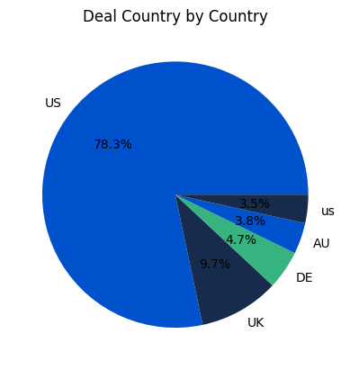

[figure not shown]

```
Stage    Closed Lost  Closed Won  Win Ratio
Country
CA               1.0         3.0   0.750000
UK               3.0         5.0   0.625000
US              33.0        39.0   0.541667
NL               2.0         2.0   0.500000
UA               1.0         1.0   0.500000
us               3.0         1.0   0.250000
```

```python
# Group by 'Country' and 'Stage' and count the number of deals and sort with highest #won on top.
country_opps = new_business.groupby(['Country', 'Stage']).size().unstack().sort_values('Closed Won', ascending=False).dropna()

#among all closed opportunities, conducting a simple visualization of the share of closed deals where a country was recorded.
country_opps_total = close_ops['Country'].value_counts().dropna().head(5)

country_opps_total.plot.pie(autopct='%1.1f%%')
plt.title('Deal Country by Country')
plt.ylabel('')
plt.show()

# Plotting a bar graph to compare the lost and won for each country source.
country_opps.plot(kind='bar')
plt.xlabel('Country')
plt.ylabel('Count')
plt.title('Number of Deals Won or Lost by Country (top 8)')
plt.xticks(rotation=45)
plt.show()

#calculate the won/lost percentages for each of the top 6 won leads
country_opps = country_opps.copy()
country_opps.loc[:, 'Win Ratio'] = country_opps['Closed Won'] / (country_opps['Closed Won'] + country_opps['Closed Lost'])
print(country_opps.sort_values('Win Ratio', ascending=False))
```

### Per Country Analysis and Opportunities

When considering the globalization strategy of the SMB segment and opportunitites for expansion, it's helpful to understand areas of opportunities and cultural sensitivities. Largely we can see that there's a high CVR within specific countries such as Canada which may indicate opportunities of asset localization and vertical growth in 2018. We can also see how there is a duplication of values such as US as us.

Data Discrepency: Its noted that the CVR (win ratio) is recorded higher than when looking at the entire dataset of new business opportunities. During analysis by country, we dropped entries where the country was not recorded along with the opportunity. This is likeley where we're observing a higher ratio. Assumptions will not be made on the positive win ratio when more details are recorded in the opportunity.